### **Brenner Swenson - 190046406**

# YouTube Comment Sentiment Analysis & Video Growth Trends

### A Tiny Data Science Project - PRD1 A 2019/20

## Research question 1

### 1.01 Necessary imports

### 1.10 Code Used to Scrape YouTube Comments

##### 1.11 A small example of scraping data on 3 videos, limiting comment extraction to 30 seconds per video for demo purposes

##### 1.12 The comment-level data and video-level data are then merged to create a complete dataset

### 1.2 Aggregation, Manipulation and Preparation of Comment Data

##### 1.21 Data loading, comment language detection

##### 1.22 Prepare the comments for sentiment analysis

### 1.3 Sentiment analysis

##### 1.31 Calculate sentiment probabilities

##### 1.32 Visualise sentiment distributions

##### 1.33 Calculate video-level features/statistics

##### 1.34 Can we find the most controversial videos without looking at likes and dislikes?

##### 1.35 Visualise video-level sentiment scores and quantify relationship with like/dislike_ratio

##### 1.36 Outlier removal, correlation analysis, and modeling

## Research question 2

### 2.01 Obtain Video Level Data Over Time

### 2.10 Load and transform the data

##### 2.11 Load in .json files collected over time and create Pandas DataFrame with all 307 files

##### 2.12 Aggregation, feature creation, and cleaning

##### 2.13 Additional feature creation: viewcount gradient/derivative with respect to time

### 2.20 Viral video growth analysis

##### 2.21 Filter the dataset to viral videos

##### 2.22 Calculate growth feature correlations for each video

##### 2.23 Random video sampling for visualisation

##### 2.24 Time series visualisation of all viral videos

### 2.30 Video characteristic analysis including non-viral videos

##### 2.33 Plot video characteristics for all videos published in the last 3 years; observations

# 1.To what extent is the median sentiment of YouTube video comments related to or a predictor of the like to dislike ratio?

### 1.01 Necessary imports

```python
import warnings
warnings.filterwarnings("ignore")

import statsmodels.api as sm
import seaborn as sns
import matplotlib.pyplot as plt
import altair as alt
import scipy as sp
from scipy.stats import chi2
import random
from nltk.stem import WordNetLemmatizer
from io import StringIO
from csv import writer
import requests
from selenium import webdriver
import time
import swifter
from bs4 import BeautifulSoup as soup


import glob
from datetime import timedelta
import traceback
import matplotlib as mpl

from nltk.sentiment.vader import SentimentIntensityAnalyzer
from emoji import demojize

from langdetect import detect
import json
import multiprocessing as mp
from datetime import datetime

import os
from tqdm import tqdm

import numpy as np
import pafy
import pandas as pd
from pathos.multiprocessing import ProcessingPool as Pool


sns.set()

rc = {
    "axes.facecolor": "white",
    "axes.edgecolor": "black",
    "font.family": ["serif"],
    "grid.color": "gainsboro",
    "grid.linestyle": "-",
    "patch.edgecolor": "none",
}
sns.set_style(rc=rc)
sns.set_context("notebook", font_scale=0.8)
mpl.rcParams["figure.edgecolor"] = "black"
mpl.rcParams["axes.linewidth"] = 0.5

tqdm.pandas()
alt.data_transformers.disable_max_rows()

from IPython.core.display import display, HTML
display(HTML("<style>.container { width:85% !important; }</style>"))

pd.set_option("display.max_columns", 500)
```

### 1.10 Code Used to Scrape YouTube Comments

Below is the code forked from [github](https://github.com/pseudobrilliant/youtube_analyzer) used to parse the HTML and build out my own dataset.

A succinct explanation of the code flow:

`get_random_links` is the function used to obtain random YouTube links for analysis. I use a lexicon of the most used English words from a [github repo](https://github.com/first20hours/google-10000-english/blob/master/20k.txt). The words are randomly sampled, and then filtered down to less than 12 characters. Depending on the amount of links, `find_instance_links` is then used to query YouTube based on each random word, which in turn returns HTML source. The HTML source contains dozens of video links; the links are then extracted from the HTML source and one link is randomly selected from the search query.

The HTML source, or `resp` is ultimately fed to an instance of `CommentParser`, where the video data is extracted, and the comments data is subsequently extracted using the `VideoMetaData` and `CommentData` classes.

```python
# Scraping code forked from https://github.com/pseudobrilliant/youtube_analyzer
# This is how I am pulling the data
class VideoMetadata:
    """Extract video meta data from BeautifulSoup parser object"""

    def __init__(self, parser):

        self.title = None
        self.desc = None
        self.publish_date = None
        self.author = None
        self.views = None
        self.likes = None
        self.dislikes = None

        self._get_video_metadata(parser)

    def _get_video_metadata(self, parser):
        """Searches the page for video metadata (uploaded, author, description, etc)"""

        self._parse_title(parser)
        self._parse_description(parser)
        self._parse_published(parser)
        self._parse_author(parser)
        self._parse_views(parser)
        self._parse_likes_dislikes(parser)

    def _parse_title(self, parser):
        """Prases the video Title"""
        title = parser.title
        if title:
            self.title = title.string.replace(" - YouTube", "")

    def _parse_description(self, parser):
        """Parses the video description"""
        description_block = parser.find("div", id="description")
        if description_block:
            self.desc = "\n".join(description_block.strings)

    def _parse_published(self, parser):
        """Parses the publish date"""
        date_block = parser.find("div", id="date")
        if date_block and date_block.text:
            date = date_block.text.replace("•", "")
            self.publish_date = date

    def _parse_author(self, parser):
        """Parses the author"""
        owner = parser.find("yt-formatted-string", class_="ytd-channel-name")
        if owner and owner.a and owner.a.string:
            self.author = owner.a.string

    def _parse_views(self, parser):
        """Parses the view count"""
        count_block = parser.find("span", class_="view-count")
        if count_block and count_block.string:
            count = count_block.string.replace(" views", "")
            self.views = count

    def _parse_likes_dislikes(self, parser):
        """Parse the likes and dislikes for the video"""
        views_block = parser.find_all(
            "yt-formatted-string", id="text", class_="ytd-toggle-button-renderer"
        )
        if views_block and views_block[0].get("aria-label"):
            likes = views_block[0]["aria-label"].replace(" likes", "").replace(" like", "")
            self.likes = likes

        if views_block and views_block[1].get("aria-label"):
            dislikes = views_block[1]["aria-label"].replace(" dislikes", "").replace(" dislike", "")
            self.dislikes = dislikes

    def to_json(self):
        """Returns all video metadata as a dictionary"""

        json = {
            "title": self.title,
            "description": self.desc,
            "published": self.publish_date,
            "channel": self.author,
            "views": self.views,
            "video_likes": self.likes,
            "video_dislikes": self.dislikes,
        }

        return json


def scrape(url):
    """Scrape youtube url for comments"""
    content = get_content(url)
    return content


def get_content(url, headless=True, pause=4):
    """Use selenium browser automation to open a youtube url, scroll to bottom and return the full page source"""
    # Configure selenium webdriver for Chrome and headless option if enabled
    options = webdriver.ChromeOptions()
    options.headless = headless
    driver = webdriver.Chrome(options=options, service_log_path=os.devnull)

    # Load URL, if url does not exist then selenium will crash out
    driver.get(url)

    print(f"Successfully loaded page: {url}")

    time.sleep(pause)

    # Youtube does not load all comments automatically and therefore we need to scroll to the bottom of the page.
    scroll(driver, failed_attempts=3)
    content = driver.page_source
    driver.close()
    return content


def scroll(driver, pause=2, delta=1000, failed_attempts=5):
    """
    Scroll to the bottom of the automated browser instance using webdriver.
    Depending on number of comments, this may take some time to scroll through to the bottom.
    inspired by https://stackoverflow.com/questions/47039874/scrape-dynamic-html-youtube-comments
    """

    print("Scrolling to bottom of page. This may take a while depending on number of comments.")

    # Try to see if window has a size (i.e not headless) otherwise we will stick with default
    height = driver.execute_script("return window.outerHeight")
    if height > 0:
        delta = height

    landed = 0
    target = delta

    failed = failed_attempts
    start = datetime.now()
    time_delta = 0

    while time_delta < 30:  # limit the scrolling to five minutes per video
        driver.execute_script("window.scrollTo({},{})".format(landed, target))
        time.sleep(pause)
        landed = driver.execute_script("return window.pageYOffset")

        # i.e haven't moved
        if landed < target:
            if failed == 0:
                print("Failed to scroll too many times! Breaking loop")
                break
            else:
                print("Failed to continue scrolling, trying again")
                failed -= 1
                print(f"Failed attempts: {failed}")
                continue
        else:
            failed = failed_attempts  # reset the failure counter

        target = landed + delta
        now = datetime.now()
        time_delta = (now - start).seconds

    print(f"Time elapsed: {time_delta} seconds")


class CommentData(object):
    def __init__(self, parser):
        self.author = None
        self.created = None
        self.comment = None
        self.likes = 0
        self.dislikes = 0
        self._get_content_data(parser)

    def _get_content_data(self, parser):
        """Searches the page for video metadata (uploaded, author, description, etc)"""

        self._parse_author(parser)
        self._parse_created(parser)
        self._parse_comment(parser)
        self._parse_likes_dislikes(parser)

    def _parse_author(self, parser):
        """Parse comment author as string"""

        author_block = parser.find("a", id="author-text")
        if author_block and author_block.span and author_block.span.string:
            author = author_block.span.string
            self.author = author.strip()

    def _parse_created(self, parser):
        """Parse comment create date"""
        header_block = parser.find("div", id="header-author")
        if header_block:
            created = header_block.find("yt-formatted-string").string
            self.created = created

    def _parse_comment(self, parser):
        """Prase comment itself and add to object"""
        comment_block = parser.find("yt-formatted-string", id="content-text")
        comment = ""

        if comment_block:
            for line in comment_block.strings:
                simple_line = line.replace("\n", " ")
                comment += simple_line.strip() + " "

            self.comment = comment

    def _parse_likes_dislikes(self, parser):
        """Parse comment likes, YouTube unfortunately doens't disclose comment dislikes"""
        views_block = parser.find("span", id="vote-count-middle")
        if views_block and views_block.get("aria-label"):
            likes = views_block["aria-label"].replace(" likes", "").replace(" like", "")
            self.likes = likes

    def to_json(self):
        """Return comment metadata as dictionary"""
        json = {
            "comment_author": self.author,
            "comment_created": self.created,
            "comment": self.comment,
            "comment_likes": self.likes,
            "comment_dislikes": self.dislikes,
        }

        return json


class CommentParser(object):
    """Parse comment data"""

    def __init__(self, source):
        parser = soup(source, "html5lib")  # load HTML source data as bs4 object
        self.video_metadata = VideoMetadata(parser)
        self.comments = []
        self._parse_comments(parser)

    def _parse_comments(self, parser):
        """Parse all of the comments on the page"""
        comment_blocks = parser.find_all("div", id="main", class_="ytd-comment-renderer")
        for blk in comment_blocks:
            comment = CommentData(blk)
            if comment.author is not None and comment.author != "":
                self.comments.append(comment)
        print(f"{len(self.comments)} comments extracted")

    def to_json(self):
        """Export all comments to nested dictionary"""
        json = []
        for c in self.comments:
            json.append(c.to_json())
        return json


# random YouTube URL code from https://stackoverflow.com/a/30965676
# Functions to find random youtube videos
def find_instance_links(word):
    """Query YouTube with randomly generated word, search for 'watch?v=...' in the HTML
    source, and return a random link from the page source."""
    base_url = "https://www.youtube.com/results?search_query="
    url = base_url + word
    print(f"Random search word: {word}")

    r = requests.get(url)
    text = r.text

    links = {}
    pos = 0
    while True:
        link, pos = find_watch(text, pos)  # find links in HTML source
        if link == None or pos == None:
            break
        pos += 1
        if ";" in link:
            continue
        links[link] = 1
    try:
        choice = random.choice(list(links.keys()))
    except IndexError:
        choice = None
    return choice


def find_watch(text, pos):
    """Return all instances in HTML source where "watch?v=" is mentioned"""
    start = text.find("watch?v=", pos)
    if start < 0:
        return None, None
    end = text.find(" ", start)
    if end < 0:
        return None, None

    if end - start > 200:  # silly heuristics, probably not a must
        return None, None

    return text[start : end - 1], start


def get_random_links(num_links=10):
    """Choose random words from 20k most used English words. Search YouTube with random words
    and extract random YouTube video links for scraping."""
    total_words = pd.read_csv("20k_most_used_words.txt", sep=" ", header=None)
    total_words.columns = ["word"]
    total_words = total_words["word"].to_list()
    random.shuffle(total_words)
    total_words = [
        w for w in total_words if 3 <= len(str(w)) <= 12
    ]  # limit the length of the words to not be verbose
    total_words = total_words[:num_links]  # limit amount of words to query for
    links = list()
    for i, word in zip(range(num_links), total_words):
        link = find_instance_links(word)
        if isinstance(link, str):
            link = link[:19]  # extract the right part of URL
            if len(link) == 19:
                links.append(link)
                print(f"Retrieved {link} from word: {word}, link number {i + 1}")
    return links
```

#### 1.11 An example of scraping data on 3 videos, limiting comment extraction to 30 seconds per video for demo

```python
links = get_random_links(3)
```

```
Random search word: policy
Retrieved watch?v=DPOqUgXVTYQ from word: policy, link number 1
Random search word: enom
Retrieved watch?v=_rs52auqcmE from word: enom, link number 2
Random search word: quicktime
Retrieved watch?v=SRJScziBTxU from word: quicktime, link number 3
```

```python
videos_results = list()
comments_results = list()

for idx, url in enumerate(links):
    print(url, idx + 1)
    resp = scrape(f"https://www.youtube.com/{url}")
    res = CommentParser(resp)
    video_data = res.video_metadata.to_json()
    video_data["url"] = url
    videos_results.append(video_data)
    comments_data = res.to_json()
    for d in comments_data:
        d.update({"url": url})
    comments_results.extend(comments_data)
```

```
watch?v=DPOqUgXVTYQ 1
Successfully loaded page: https://www.youtube.com/watch?v=DPOqUgXVTYQ
Scrolling to bottom of page. This may take a while depending on number of comments.
Failed to continue scrolling, trying again
Failed attempts: 2
Failed to continue scrolling, trying again
Failed attempts: 2
Failed to continue scrolling, trying again
Failed attempts: 2
Failed to continue scrolling, trying again
Failed attempts: 2
Time elapsed: 30 seconds
80 comments extracted
watch?v=_rs52auqcmE 2
Successfully loaded page: https://www.youtube.com/watch?v=_rs52auqcmE
Scrolling to bottom of page. This may take a while depending on number of comments.
Failed to continue scrolling, trying again
Failed attempts: 2
Failed to continue scrolling, trying again
Failed attempts: 2
Failed to continue scrolling, trying again
Failed attempts: 2
Failed to continue scrolling, trying again
Failed attempts: 2
Time elapsed: 30 seconds
80 comments extracted
watch?v=SRJScziBTxU 3
Successfully loaded page: https://www.youtube.com/watch?v=SRJScziBTxU
Scrolling to bottom of page. This may take a while depending on number of comments.
Failed to continue scrolling, trying again
Failed attempts: 2
Failed to continue scrolling, trying again
Failed attempts: 2
Failed to continue scrolling, trying again
Failed attempts: 2
Failed to continue scrolling, trying again
Failed attempts: 2
Failed to continue scrolling, trying again
Failed attempts: 1
Failed to continue scrolling, trying again
Failed attempts: 0
Failed to scroll too many times! Breaking loop
Time elapsed: 24 seconds
60 comments extracted
```

#### 1.12 The comment-level data and video-level data are then merged

```python
comment_sample_df = pd.DataFrame(comments_results)
video_sample_df = pd.DataFrame(videos_results)
comment_sample_df = comment_sample_df.merge(video_sample_df, how="left", on="url")
display(comment_sample_df.sample(10, random_state=42))
```

|  | comment_author | comment_created | comment | comment_likes | comment_dislikes | url | title | description | published | channel | views | video_likes | video_dislikes |
| --- | --- | --- | --- | --- | --- | --- | --- | --- | --- | --- | --- | --- | --- |
| 132 | KinKin World | 2 months ago | Like if Joyner Lucas and russ should do a song... | 13 | 0 | watch?v=_rs52auqcmE | Joyner Lucas - I Love (ADHD) | Download / Stream I LOVE \nhttps://JoynerLucas... | 17 Oct 2018 | Joyner Lucas | 57,417,209 | 670,212 | 20,809 |
| 148 | Konrad Krolczyk | 2 weeks ago | Joyner Lucas deserves his own site so he’s not... | 4 | 0 | watch?v=_rs52auqcmE | Joyner Lucas - I Love (ADHD) | Download / Stream I LOVE \nhttps://JoynerLucas... | 17 Oct 2018 | Joyner Lucas | 57,417,209 | 670,212 | 20,809 |
| 93 | Only Kid | 13 hours ago | Friend :who's your favorite rapper Me:Joyner ... | 2 | 0 | watch?v=_rs52auqcmE | Joyner Lucas - I Love (ADHD) | Download / Stream I LOVE \nhttps://JoynerLucas... | 17 Oct 2018 | Joyner Lucas | 57,417,209 | 670,212 | 20,809 |
| 180 | Brazer Studio | 1 year ago | thanks bro, really helped | 0 | 0 | watch?v=SRJScziBTxU | How To Download And Install QuickTime (Adobe A... | ---------------------------------------------... | 14 Jan 2017 | NetGlow WORLD | 66,938 | 527 | 90 |
| 15 | Raju Kairam konda | 11 months ago | Chala bhaga chepparu sir, tq | 0 | 0 | watch?v=DPOqUgXVTYQ | Jeevan Labh Policy \|\| C.S.Siva Kumar \|\| Telugu... | Please watch: "Every Mother Should Be Courageo... | 13 Sep 2018 | SumanTV Life | 300,715 | 2,889 | 223 |
| 115 | Mo lester | 11 months ago (edited) | I edited this comment so know one knows why I ... | 3.3K | 0 | watch?v=_rs52auqcmE | Joyner Lucas - I Love (ADHD) | Download / Stream I LOVE \nhttps://JoynerLucas... | 17 Oct 2018 | Joyner Lucas | 57,417,209 | 670,212 | 20,809 |
| 172 | SB Music | 2 years ago | Keep it up bro | 1 | 0 | watch?v=SRJScziBTxU | How To Download And Install QuickTime (Adobe A... | ---------------------------------------------... | 14 Jan 2017 | NetGlow WORLD | 66,938 | 527 | 90 |
| 209 | Nightcore Bunny | 2 years ago | Can you a tutorial on how to fix a rendering p... | 0 | 0 | watch?v=SRJScziBTxU | How To Download And Install QuickTime (Adobe A... | ---------------------------------------------... | 14 Jan 2017 | NetGlow WORLD | 66,938 | 527 | 90 |
| 75 | Praveen Kumar | 1 year ago | Do not tell about lic .....Just tell term insu... | 0 | 0 | watch?v=DPOqUgXVTYQ | Jeevan Labh Policy \|\| C.S.Siva Kumar \|\| Telugu... | Please watch: "Every Mother Should Be Courageo... | 13 Sep 2018 | SumanTV Life | 300,715 | 2,889 | 223 |
| 142 | Jairo Tv | 4 days ago | King Bach Brought Me Here.🤗🔥 | 1 | 0 | watch?v=_rs52auqcmE | Joyner Lucas - I Love (ADHD) | Download / Stream I LOVE \nhttps://JoynerLucas... | 17 Oct 2018 | Joyner Lucas | 57,417,209 | 670,212 | 20,809 |

### 1.2 Aggregation, Manipulation and Preparation of Comment Data

#### 1.21 Data loading, comment language detection

The data is loaded via each indivdual .csv file saved over time, then concatenated to create a larger master data set `master_df`.

The `like/dislike_ratio` is then derived, using the following:

$$like\,dislike\,ratio = \frac{video\,likes}{video\,likes + video\,dislikes}$$

```python
def convert_cols_to_numeric(master_df):
    """Use regex to parse extracted text data containing numeric values and convert to floats"""
    NUMERIC_COLS = ["comment_likes", "views", "video_dislikes", "video_likes"]

    master_df["comment"] = master_df["comment"].astype(str)

    for num_col in NUMERIC_COLS:
        master_df[num_col] = (
            master_df[num_col].str.extract(r"(\d{1,3}(?:[,]\d{3})*)", expand=False).fillna("")
        )
        master_df[num_col] = pd.to_numeric(master_df[num_col].str.replace(",", ""))

    return master_df


# Mahalanobis function taken from https://www.machinelearningplus.com/statistics/mahalanobis-distance/
def mahalanobis(x=None, data=None, cov=None):
    """Compute the Mahalanobis Distance between each row of x and the data
    x    : vector or matrix of data with, say, p columns.
    data : ndarray of the distribution from which Mahalanobis distance of each observation of x is to be computed.
    cov  : covariance matrix (p x p) of the distribution. If None, will be computed from data.
    """
    x_minus_mu = x - np.mean(data)
    if not cov:
        cov = np.cov(data.values.T)
    inv_covmat = sp.linalg.inv(cov)
    left_term = np.dot(x_minus_mu, inv_covmat)
    mahal = np.dot(left_term, x_minus_mu.T)
    return mahal.diagonal()


def sentiment(comment, analyzer):
    "Return compound sentiment polarity scores using NLTK Sentiment Analyzer."
    score = analyzer.polarity_scores(comment)["compound"]
    return score


def detect_language(text):
    "Return language of text using langdetect."
    try:
        lang = detect(text)
    except:
        lang = None
    return lang


# lists taken from https://towardsdatascience.com/twitter-sentiment-analysis-using-fasttext-9ccd04465597
def load_dict_smileys():
    """Return mappings of emoticon to corresponding representative emotion."""

    return {
        ":‑)": "happy",
        ":-]": "happy",
        ":-3": "happy",
        ":->": "happy",
        "8-)": "happy",
        ":-}": "happy",
        ":)": "happy",
        ":]": "happy",
        ":3": "happy",
        ":>": "happy",
        "8)": "happy",
        ":}": "happy",
        ":o)": "happy",
        ":c)": "happy",
        ":^)": "happy",
        "=]": "happy",
        "=)": "happy",
        ":-))": "happy",
        ":‑D": "happy",
        "8‑D": "happy",
        "x‑D": "happy",
        "X‑D": "happy",
        ":D": "happy",
        "8D": "happy",
        "xD": "happy",
        "XD": "happy",
        ":‑(": "sad",
        ":‑c": "sad",
        ":‑<": "sad",
        ":‑[": "sad",
        ":(": "sad",
        ":c": "sad",
        ":<": "sad",
        ":[": "sad",
        ":-||": "sad",
        ">:[": "sad",
        ":{": "sad",
        ":@": "sad",
        ">:(": "sad",
        ":'‑(": "sad",
        ":'(": "sad",
        ":‑P": "playful",
        "X‑P": "playful",
        "x‑p": "playful",
        ":‑p": "playful",
        ":‑Þ": "playful",
        ":‑þ": "playful",
        ":‑b": "playful",
        ":P": "playful",
        "XP": "playful",
        "xp": "playful",
        ":p": "playful",
        ":Þ": "playful",
        ":þ": "playful",
        ":b": "playful",
        "<3": "love",
    }


def load_dict_contractions():
    """Return mappings of contractions to corresponding expanded phrases."""

    return {
        "ain't": "is not",
        "amn't": "am not",
        "aren't": "are not",
        "can't": "cannot",
        "'cause": "because",
        "couldn't": "could not",
        "couldn't've": "could not have",
        "could've": "could have",
        "daren't": "dare not",
        "daresn't": "dare not",
        "dasn't": "dare not",
        "didn't": "did not",
        "doesn't": "does not",
        "don't": "do not",
        "e'er": "ever",
        "em": "them",
        "everyone's": "everyone is",
        "finna": "fixing to",
        "gimme": "give me",
        "gonna": "going to",
        "gon't": "go not",
        "gotta": "got to",
        "hadn't": "had not",
        "hasn't": "has not",
        "haven't": "have not",
        "he'd": "he would",
        "he'll": "he will",
        "he's": "he is",
        "he've": "he have",
        "how'd": "how would",
        "how'll": "how will",
        "how're": "how are",
        "how's": "how is",
        "I'd": "I would",
        "I'll": "I will",
        "I'm": "I am",
        "I'm'a": "I am about to",
        "I'm'o": "I am going to",
        "isn't": "is not",
        "it'd": "it would",
        "it'll": "it will",
        "it's": "it is",
        "I've": "I have",
        "kinda": "kind of",
        "let's": "let us",
        "mayn't": "may not",
        "may've": "may have",
        "mightn't": "might not",
        "might've": "might have",
        "mustn't": "must not",
        "mustn't've": "must not have",
        "must've": "must have",
        "needn't": "need not",
        "ne'er": "never",
        "o'": "of",
        "o'er": "over",
        "ol'": "old",
        "oughtn't": "ought not",
        "shalln't": "shall not",
        "shan't": "shall not",
        "she'd": "she would",
        "she'll": "she will",
        "she's": "she is",
        "shouldn't": "should not",
        "shouldn't've": "should not have",
        "should've": "should have",
        "somebody's": "somebody is",
        "someone's": "someone is",
        "something's": "something is",
        "that'd": "that would",
        "that'll": "that will",
        "that're": "that are",
        "that's": "that is",
        "there'd": "there would",
        "there'll": "there will",
        "there're": "there are",
        "there's": "there is",
        "these're": "these are",
        "they'd": "they would",
        "they'll": "they will",
        "they're": "they are",
        "they've": "they have",
        "this's": "this is",
        "those're": "those are",
        "'tis": "it is",
        "'twas": "it was",
        "wanna": "want to",
        "wasn't": "was not",
        "we'd": "we would",
        "we'd've": "we would have",
        "we'll": "we will",
        "we're": "we are",
        "weren't": "were not",
        "we've": "we have",
        "what'd": "what did",
        "what'll": "what will",
        "what're": "what are",
        "what's": "what is",
        "what've": "what have",
        "when's": "when is",
        "where'd": "where did",
        "where're": "where are",
        "where's": "where is",
        "where've": "where have",
        "which's": "which is",
        "who'd": "who would",
        "who'd've": "who would have",
        "who'll": "who will",
        "who're": "who are",
        "who's": "who is",
        "who've": "who have",
        "why'd": "why did",
        "why're": "why are",
        "why's": "why is",
        "won't": "will not",
        "wouldn't": "would not",
        "would've": "would have",
        "y'all": "you all",
        "you'd": "you would",
        "you'll": "you will",
        "you're": "you are",
        "you've": "you have",
        "Whatcha": "What are you",
        "luv": "love",
        "sux": "sucks",
        "u": "you",
        "r": "are",
        "lol": "laugh out loud",
        "rly": "really",
    }
```

```python
# Load in all of the data collected
df_15 = pd.read_csv("youtube_comments_data_20191015.csv")
df_16 = pd.read_csv("youtube_comments_data_20191016.csv")
df_17 = pd.read_csv("youtube_comments_data_20191017.csv")
df_20 = pd.read_csv("youtube_comments_data_20191020.csv")
df_23a = pd.read_csv("youtube_comments_data_20191023-a.csv")
df_23b = pd.read_csv("youtube_comments_data_20191023-b.csv")
df_23c = pd.read_csv("youtube_comments_data_20191023-c.csv")
df_24a = pd.read_csv("youtube_comments_data_20191024-a.csv")
df_24b = pd.read_csv("youtube_comments_data_20191024-b.csv")
df_26a = pd.read_csv("youtube_comments_data_20191026-a.csv")
df_26b = pd.read_csv("youtube_comments_data_20191026-b.csv")
df_28a = pd.read_csv("youtube_comments_data_20191028-a.csv")
df_28b = pd.read_csv("youtube_comments_data_20191028th-b.csv")


master_df = pd.concat(
    [
        df_15,
        df_16,
        df_17,
        df_20,
        df_23a,
        df_23b,
        df_23c,
        df_24a,
        df_24b,
        df_26a,
        df_26b,
        df_28a,
        df_28b,
    ],
    axis=0,
)
master_df = master_df.reset_index()
master_df = master_df.drop_duplicates(subset=["comment_author", "comment", "url"])
master_df = master_df.drop(columns=["Unnamed: 0"])
```

```python
# Convert data types, engineer like/dislike feature
master_df = convert_cols_to_numeric(master_df)
master_df["like/dislike_ratio"] = master_df["video_likes"] / (
    master_df["video_likes"] + master_df["video_dislikes"]
)
master_df = master_df[master_df["like/dislike_ratio"].notnull()]
```

```python
# detect languages on all comments
master_df["comment_language"] = (
    master_df["comment"]
    .swifter.progress_bar(True)
    .allow_dask_on_strings(enable=True)
    .apply(detect_language)
)
```

```python
# static data load
master_df = pd.read_csv("comments_data_with_language.csv")
```

```python
language_counts_df = (
    master_df["comment_language"].value_counts().sort_values(ascending=False).reset_index()
)
```

```python
# prepare data for visualisation
language_counts_df = language_counts_df.rename(
    columns={"comment_language": "Number of Comments", "index": "Language Code"}
)

language_counts_df["Language Code"] = language_counts_df["Language Code"].str.upper()
```

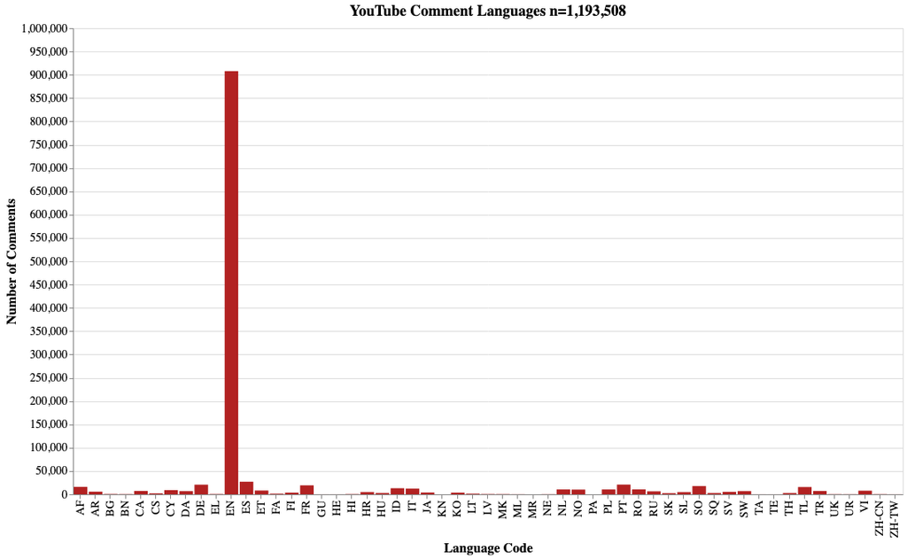

```python
# visualise the distribution of comment languages
num_comments = master_df['comment'].nunique()
chart = (
    alt.Chart(language_counts_df)
    .mark_bar()
    .encode(x="Language Code", y="Number of Comments")
    .properties(title=f"YouTube Comment Languages n={num_comments:,}", width=1000, height=562)
)
chart = chart.configure(background="white", ).configure_mark(color="firebrick")
chart = chart.configure_title(fontSize=18, font="Optima Regular")


chart = chart.configure_axis(
    labelFont="Optima Regular", titleFont="Optima Regular", labelFontSize=14, titleFontSize=16
)

chart
```

#### 1.22 Prepare the comments for sentiment analysis

To clean the comments data (most all text cleaning methods use regular expressions), all @mentions and #hashtags are removed from comments. URLs are then removed, in addition to all punctuation. The comments are then all converted to lowercase. Emoticons such as =) express a positive sentiment, so emoticons/emojis need to be encoded as the closest text representations, so `load_dict_smileys` is used in addition to the [emoji](https://github.com/carpedm20/emoji/) Python library to decode emojis like 👍 to :thumbs_up:.

Contractions are then converted to their respective expanded phrases, a small subset of stopwords are removed, references to video times (e.g. 4:59) are removed, and words are converted to their lemmas) using [NLTK's WordNetLemmatizer](https://www.nltk.org/_modules/nltk/stem/wordnet.html).

```python
# filter the data to only English comments
master_df = master_df.loc[master_df["comment_language"] == "en", :]

# remove any hashtags from the comments
master_df["comment"] = master_df["comment"].str.replace(r"(@[A-Za-z0-9]+)|(#[A-Za-z0-9]+)", " ")

# remove any URLs
master_df["comment"] = master_df["comment"].str.replace(r"(\w+:\/\/\S+)", " ")

# remove punctuation and replace them with spaces
master_df["comment"] = master_df["comment"].str.replace(r"[\.\,\!\?\;\-\=]", " ")

# make everything lowercase
master_df["comment"] = master_df["comment"].str.lower()

# replace smiley faces with words and replace contractions with full words
smileys = load_dict_smileys()
master_df["comment"] = master_df["comment"].str.split()
master_df["comment"] = master_df["comment"].swifter.apply(
    lambda x: [smileys[word] if word in smileys else word for word in x]
)

# make sure that contractions are all lowercase to match with tokens
contractions = load_dict_contractions()
contractions = {k.lower(): v for k, v in contractions.items()}
contractions = {k: v.lower() for k, v in contractions.items()}
master_df["comment"] = master_df["comment"].swifter.apply(
    lambda x: [contractions[word] if word in contractions else word for word in x]
)

# remove small set of stopwords to maintain sentiment
stop_words = ["in", "of", "at", "a", "the"]
master_df["comment"] = master_df["comment"].swifter.apply(
    lambda x: [word for word in x if word not in stop_words]
)

# convert emojis to their text representations
master_df["comment"] = master_df["comment"].str.join(" ").swifter.apply(demojize)

# remove references to times in the videos, e.g. 4:15, 10:59
master_df["comment"] = master_df["comment"].str.replace(r"[\d]{0,2}:[\d+]{0,2}", " ")

# remove colons and underscores from demoji, i.e. :laughing_face: to laughing face
master_df["comment"] = master_df["comment"].str.replace(r"[\:]", " ")
master_df["comment"] = master_df["comment"].str.replace(r"[\_]", " ")

# convert tokens to lemmas
lemmatizer = WordNetLemmatizer()
master_df["comment"] = master_df["comment"].str.split()
master_df["comment"] = master_df["comment"].swifter.apply(
    lambda x: [lemmatizer.lemmatize(w) for w in x]
)

# join comments back to full form
master_df["comment"] = master_df["comment"].str.join(" ")
```

## 1.3 Sentiment analysis

#### 1.31 Calculate sentiment probabilities

```python
# instantiate nltk SentimentIntensityAnalyzer
analyzer = SentimentIntensityAnalyzer()
```

```python
# remove null comments and calculate sentiment probabilities
master_df = master_df.dropna(subset=["comment"])
master_df["sentiment_probs"] = master_df.swifter.apply(
    lambda row: sentiment(comment=row["comment"], analyzer=analyzer), axis=1
)
```

#### 1.32 Visualise sentiment distributions

The distribution of all comment sentiment probabilties are then plottted; a large spike at 0.0 is observed, indicating neutral sentiment. The neutral comments require removal for more effective analysis as they are not informative.

Samples of neutral, positive, and negative sentiment comments are displayed. The same distribution plot is shown again with the neutral values removed.

```python
# static data load
master_df = pd.read_csv("sentiment_data_checkpoint_post_sentiment.csv")
```

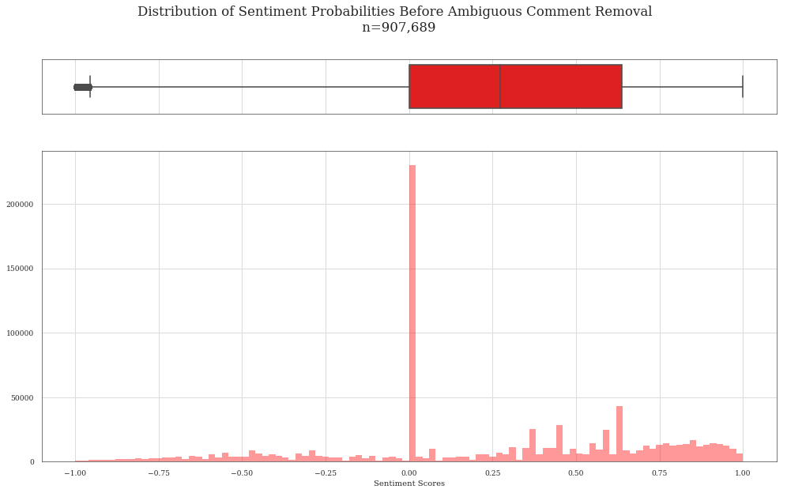

```python
num_comments = master_df.shape[0]
f, (ax_box, ax_hist) = plt.subplots(
    2, figsize=(16, 9), sharex=True, gridspec_kw={"height_ratios": (0.15, 0.85)}, dpi=75
)
f.suptitle(f"Distribution of Sentiment Probabilities Before Ambiguous Comment Removal \n n={num_comments:,}", size=16)
sns.boxplot(master_df["sentiment_probs"], ax=ax_box, color='red')
sns.distplot(master_df["sentiment_probs"], ax=ax_hist, bins=100, color='red',norm_hist=False, kde=False)
ax_hist.set(xlabel="Sentiment Scores", ylabel="")
ax_box.set(xlabel="", ylabel="");
```

```python
# Comments with neutral sentiment
master_df.loc[master_df["sentiment_probs"] == 0, "comment"].sample(10, random_state=41)
```

```
48984                                                120fps
225555               memory when i wa junior high school 95
444134      and this is why we need to nominate andrew yang
47395            who else came here because netty schribble
848174    "the way that he is portrayed tv show " a oppo...
623844                        short ghanaian british rapper
557220                       only date i can have real life
674409    i will need this song for my own family becaus...
316144                            who listening august 2019
646308                                when i see you celtic
Name: comment, dtype: object
```

```python
# Comments with extremely positive sentiment
master_df.loc[master_df["sentiment_probs"] >= 0.80, "comment"].sample(10, random_state=41)
```

```
824857    just love them so much going to see them tomor...
73162     awesome tutorial best i’ve seen will defo be s...
752247    i planned to apply au whv this year and your v...
656770           uzi always picking ez he better other hero
711383    beautifully executed and result and clearly ar...
392200             please god i want to love this new album
209939    tyler messing around and doing stupid stuff to...
807493           i miss seoul so much love love from sweden
92278     my friend hannah had huntington when i met her...
471235    who else is loyal fan azzy revolving heart diz...
Name: comment, dtype: object
```

```python
# Comments with extremely negative sentiment
master_df.loc[master_df["sentiment_probs"] <= -0.80, "comment"].sample(10, random_state=41)
```

```
51970     all mom seriously hated this one worried face ...
524200    why hell do you think it’s okay to promote thi...
322283    why is everybody so damn crazy what is wrong w...
644578    you claim all these mistake but really you’re ...
143314    i felt really sad how did they have courage to...
634457               make my day while been heartbroken sad
537156    you can say what you want about american soldi...
725947    why is podcast's audio always so goddamn low e...
477370    obama administration made decision with very l...
651082    security guard cannot just go up to someone an...
Name: comment, dtype: object
```

```python
# Remove comments with neutral sentiment
master_df = master_df.loc[master_df["sentiment_probs"] != 0, :]
```

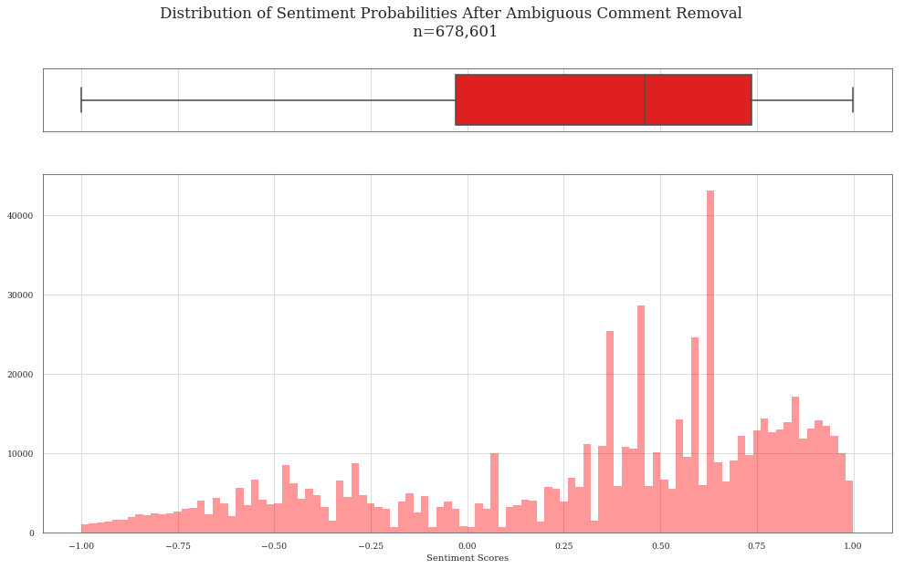

```python
num_comments = master_df.shape[0]
f, (ax_box, ax_hist) = plt.subplots(
    2, figsize=(16, 9), sharex=True, gridspec_kw={"height_ratios": (0.15, 0.85)}, dpi=75
)
f.suptitle(f"Distribution of Sentiment Probabilities After Ambiguous Comment Removal \n n={num_comments:,}", size=16)
sns.boxplot(master_df["sentiment_probs"], ax=ax_box, color='red')
sns.distplot(master_df["sentiment_probs"], ax=ax_hist, bins=100, color='red', norm_hist=False, kde=False)
ax_hist.set(xlabel="Sentiment Scores", ylabel="")
ax_box.set(xlabel="", ylabel="")
f.savefig("sentiment_probabilities.png", bbox_inches="tight");
```

#### 1.33 Calculate video-level features/statistics

```python
# calculate summary statistics grouped by video url
grouped = master_df.groupby("url")
grouped_comment_likes_median = grouped.median()["comment_likes"]
sent_score_median = grouped.median()["sentiment_probs"]
sent_score_std = grouped.std()["sentiment_probs"]
sent_score_mean = grouped.mean()["sentiment_probs"]
max_sent_score = grouped.max()["sentiment_probs"]
min_sent_score = grouped.min()["sentiment_probs"]
comment_count = grouped.count()["comment"]
```

```python
# merge all of the above created summary statistics back with comments DataFrame and remove all but one
# row for each video
master_df = master_df.merge(sent_score_median.rename("sent_score_median"), how="left", on="url")
master_df = master_df.merge(sent_score_mean.rename("sent_score_mean"), how="left", on="url")
master_df = master_df.merge(sent_score_std.rename("sent_score_std"), how="left", on="url")
master_df = master_df.merge(
    grouped_comment_likes_median.rename("comment_likes_median"), how="left", on="url"
)
master_df = master_df.merge(max_sent_score.rename("max_sent_score"), how="left", on="url")
master_df = master_df.merge(min_sent_score.rename("min_sent_score"), how="left", on="url")
master_df = master_df.merge(comment_count.rename("comment_count"), how="left", on="url")
master_df["sent_range"] = master_df["max_sent_score"] - master_df["min_sent_score"]
master_df["sent_score_cv"] = master_df["sent_score_std"] / master_df["sent_score_mean"]
```

[figure not shown]

```python
# Distribution of comment sentiment ranges among videos
num_videos = master_df['url'].nunique()
f, ax_hist = plt.subplots(figsize=(16, 9), dpi=75)
f.suptitle(f"Distribution of Video Comment Sentiment Range \n n={num_videos:,}", size=16)
sns.distplot(master_df["sent_range"], ax=ax_hist, bins=100, color='red', norm_hist=False, kde=False)
ax_hist.set(xlabel="Sentiment Range", ylabel="");
```

#### 1.34 Can we find the most controversial videos without looking at likes and dislikes?

```python
master_df = master_df.drop_duplicates(subset=["url"])
```

```python
display(
    master_df.loc[
        (master_df["sent_range"] > 1.75)
        & (master_df["sent_score_cv"] > 13)
        & (master_df["sent_score_mean"] < 0.15),
        ["title", "channel", "like/dislike_ratio"],
    ].sample(10, random_state=11)
)
```

|  | title | channel | like/dislike_ratio |
| --- | --- | --- | --- |
| 235357 | You should uninstall QuickTime for Windows (CN... | CNET | 0.936190 |
| 667220 | 17 Tricky Questions And Riddles To Sharpen You... | 7-Second Riddles | 0.774410 |
| 239069 | IN THE TALL GRASS (2019) Ending Explained | FoundFlix | 0.984573 |
| 68684 | Living with Juvenile Huntington's Disease | HDYO | 0.972318 |
| 72614 | Car Crash Cop Argument | Charles Veitch | 0.498951 |
| 264958 | That's When You Get Member Berries | South Park Studios | 0.965492 |
| 368292 | Training an Aggressive Dog \| National Geographic | National Geographic | 0.950147 |
| 261503 | Pak-Man x Young Smokes - Active \| @PakManOnlin... | Link Up TV | 0.963459 |
| 191723 | 5 SCARIEST Live Audio Broadcast Interruptions ... | Top 5 Unknowns | 0.886297 |
| 231971 | Is Trump on the way out? - George Galloway | RT | 0.853982 |

#### 1.35 Visualise video-level sentiment scores and quantify relationship with `like/dislike_ratio`

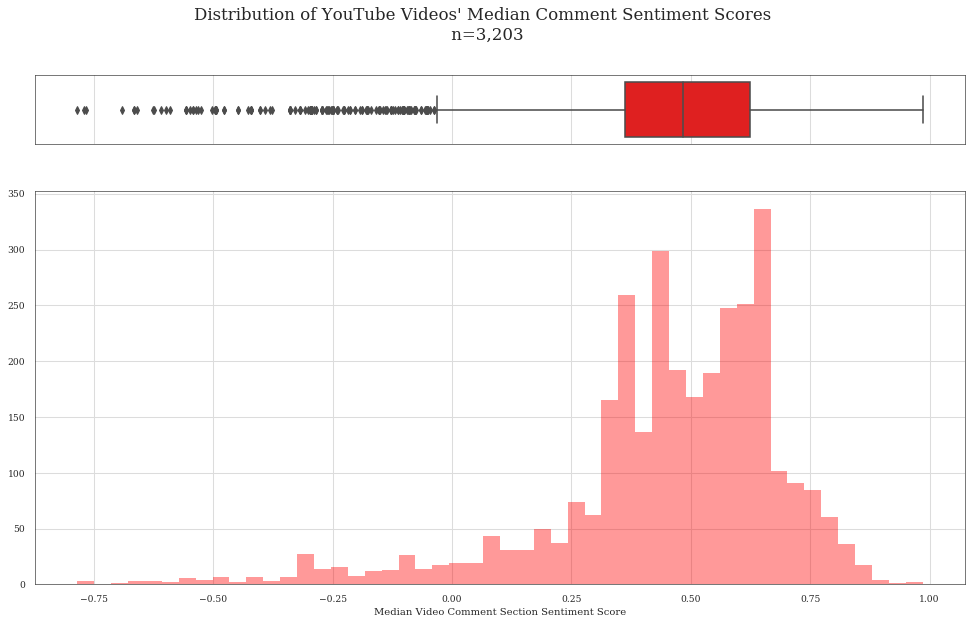

```python
# Distribution of each video's mean sentiment, can see some outliers in the bottom of the whisker plot
f, (ax_box, ax_hist) = plt.subplots(
    2, figsize=(16, 9), sharex=True, gridspec_kw={"height_ratios": (0.15, 0.85)}, dpi=75
)
f.suptitle(f"Distribution of YouTube Videos' Median Comment Sentiment Scores \n n={num_videos:,}", size=16)
sns.boxplot(master_df["sent_score_median"], ax=ax_box, color='red')
sns.distplot(master_df["sent_score_median"], ax=ax_hist, bins=50, color='red', norm_hist=False, kde=False)
ax_hist.set(xlabel="Median Video Comment Section Sentiment Score", ylabel="")
ax_box.set(xlabel="", ylabel="")
f.savefig("sentiment_probabilities.png", bbox_inches="tight");
```

#### 1.36 Outlier removal, correlation analysis, and modeling

To validate the significance of the correlation, an Ordinary Least Squares regression model is fit on the data with `sent_score_median` and `sent_range` as the features and `like/dislike_ratio` as the dependent variable.

- The coefficients:
  - `sent_score_median`
  - `sent_range`

```python
# Use Mahalanobis distance to find outliers in multidimensional space
# Mahalanobis distance requires non-null values
master_df = master_df.dropna(subset=["sent_score_std"])
master_df = master_df.dropna(subset=["views"])
master_df["mahala"] = mahalanobis(
    x=master_df[["views", "video_dislikes", "sent_score_cv"]],
    data=master_df[["views", "video_dislikes", "sent_score_cv"]],
)
```

```python
# Find threshold for Mahalanobis distance cutoff using 0.99 confidence
critical_value = chi2.ppf((1 - 0.01), df=2)
print(
    f"Critical value with two degrees of freedom with 0.01 significance level is {critical_value}"
)
```

```
Critical value with two degrees of freedom with 0.01 significance level is 9.21034037197618
```

```python
master_df.shape
```

```
(3122, 27)
```

```python
# sample of outliers for removal
display(
    master_df.loc[
        master_df["mahala"] > critical_value,
        [
            "views",
            "sent_score_cv",
            "video_likes",
            "video_dislikes",
            "like/dislike_ratio",
            "title",
            "url",
        ],
    ].sample(10, random_state=5)
)
```

|  | views | sent_score_cv | video_likes | video_dislikes | like/dislike_ratio | title | url |
| --- | --- | --- | --- | --- | --- | --- | --- |
| 268517 | 294007761.0 | 1.578677 | 1398113.0 | 73565.0 | 0.950013 | Tainy, Anuel AA, Ozuna - Adicto (Official Video) | watch?v=58u-zkDLNPg |
| 422928 | 492318.0 | 256.397157 | 45083.0 | 242.0 | 0.994661 | Roddy Ricch - Start Wit Me feat. Gunna [Offici... | watch?v=lPXmGk9dqAM |
| 236670 | 141988936.0 | 0.365308 | 432339.0 | 233987.0 | 0.648840 | ABC Song + More Nursery Rhymes & Kids Songs - ... | watch?v=71h8MZshGSs |
| 647113 | 826230912.0 | 1.862192 | 3726757.0 | 112615.0 | 0.970668 | Bruno Mars - When I Was Your Man (Official Video) | watch?v=ekzHIouo8Q4 |
| 37893 | 63526.0 | -102.717719 | 462.0 | 85.0 | 0.844607 | Turkey starts ground offensive into Syria | watch?v=0xecwNyMQQ0 |
| 450180 | 850271279.0 | 0.761643 | 835151.0 | 501393.0 | 0.624859 | Five Little Ducks \| Little Baby Bum \| Nursery ... | watch?v=tFoUuFq3vHw |
| 269318 | 538420943.0 | 0.977036 | 3354702.0 | 96525.0 | 0.972032 | Charlie Puth - "How Long" [Official Video] | watch?v=CwfoyVa980U |
| 305323 | 1559163.0 | 54.070455 | 30105.0 | 798.0 | 0.974177 | 7 Transforming Bosses Who Made Us Regret Our C... | watch?v=7v-KIxHOhrs |
| 288421 | 261408822.0 | 1.283814 | 2939549.0 | 245354.0 | 0.922963 | Logan Paul - Help Me Help You ft. Why Don't We... | watch?v=pT20g6lTZ-k |
| 253180 | 301055355.0 | 1.395967 | 1132425.0 | 46390.0 | 0.960647 | 50 Cent - Just A Lil Bit (Official Video) | watch?v=GllEDACUbNo |

```python
# remove records where mahalanobis distance figure exceeds determined critical value
master_df = master_df.loc[master_df["mahala"] <= critical_value, :]
```

```python
master_df.shape
```

```
(3054, 27)
```

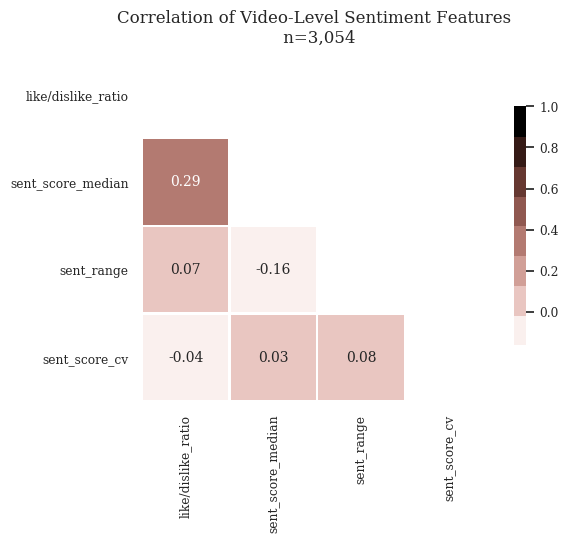

```python
# correlation matrix
fig, ax = plt.subplots(figsize=(6, 6), dpi=100)
num_videos = master_df['url'].nunique()
ax.set_title(f"Correlation of Video-Level Sentiment Features \n n={num_videos:,}", fontdict={"fontsize": 12})
corr = master_df[
    ["like/dislike_ratio", "sent_score_median", "sent_range", "sent_score_cv"]
].corr()
mask = np.triu(corr)
bottom, top = ax.get_ylim()
ax.set_ylim(bottom + 0.5, top - 0.5)
sns.heatmap(
    corr,
    mask=mask,
    cmap=sns.cubehelix_palette(8, start=4, rot=0, dark=0.0, light=0.95, reverse=False),
    annot=True,
    fmt=".2f",
    square=True,
    linewidths=1,
    cbar_kws={"shrink": 0.50},
    ax=ax,
)
fig.tight_layout();
fig.savefig("sentiment_correlations.png", bbox_inches="tight");
```

```python
# set up basic regression with likes/dislike ratio as the target variable

X = master_df[["sent_score_median", "sent_range"]]
y = master_df["like/dislike_ratio"]

X = sm.add_constant(X)
model = sm.OLS(y, X)

results = model.fit()
results.summary()
```

OLS Regression Results

| Dep. Variable: | like/dislike_ratio | R-squared: | 0.100 |
| --- | --- | --- | --- |
| Model: | OLS | Adj. R-squared: | 0.099 |
| Method: | Least Squares | F-statistic: | 168.9 |
| Date: | Sat, 14 Dec 2019 | Prob (F-statistic): | 2.70e-70 |
| Time: | 18:19:49 | Log-Likelihood: | 3866.3 |
| No. Observations: | 3054 | AIC: | -7727. |
| Df Residuals: | 3051 | BIC: | -7709. |
| Df Model: | 2 |  |  |
| Covariance Type: | nonrobust |  |  |

|  | coef | std err | t | P>\|t\| | [0.025 | 0.975] |
| --- | --- | --- | --- | --- | --- | --- |
| const | 0.8659 | 0.006 | 146.982 | 0.000 | 0.854 | 0.877 |
| sent_score_median | 0.0943 | 0.005 | 17.928 | 0.000 | 0.084 | 0.105 |
| sent_range | 0.0202 | 0.003 | 6.917 | 0.000 | 0.014 | 0.026 |

| Omnibus: | 2607.763 | Durbin-Watson: | 2.073 |
| --- | --- | --- | --- |
| Prob(Omnibus): | 0.000 | Jarque-Bera (JB): | 97235.201 |
| Skew: | -3.901 | Prob(JB): | 0.00 |
| Kurtosis: | 29.519 | Cond. No. | 11.9 |

Warnings:  
[1] Standard Errors assume that the covariance matrix of the errors is correctly specified.

# 2. What trends can we observe in how viral YouTube videos grow, and what characteristics contribute to a video’s success (or lack thereof)?

### 2.01 Obtain Video Level Data Over Time

The below script was executed every hour using a cronjob for about ~2,500 random YouTube videos that were different from the sentiment analysis sample. The script execution was ran over a two week period from 22 November to 7 December 2019.

```python
def get_video_metadata(link):
    """Use pafy to pull video-level statistics as well as channel-level statistics for supplied link."""
    now = datetime.now()
    base_url = "https://www.youtube.com/"
    try:
        video = pafy.new(base_url + link)

    except:
        print(f"OSError at {link}")
        return None

    try:
        channel = pafy.get_channel(base_url + "user/" + video.username)

    except:
        try:
            channel = pafy.get_channel(base_url + "channel/" + video.username)
        except:
            channel = None

    try:
        channel_subscriptions = [
            {x.title: {"subscriber_count": int(x.subscriberCount)}} for x in channel.subscriptions
        ]

    except:
        channel_subscriptions = None

    output_payload = {
        "as_of": now.isoformat(),
        "title": video.title,
        "description": video.description,
        "url": video.watchv_url,
        "category": video.category,
        "likes": video.likes,
        "dislikes": video.dislikes,
        "keywords": video.keywords,
        "length": video.length,
        "username": video.username,
        "author": video.author,
        "viewcount": video.viewcount,
        "rating": video.rating,
        "published": video.published,
        "channel_description": channel.description if channel else None,
        "channel_subscriptions": channel_subscriptions,
        "subscriber_count": int(channel.subscriberCount) if channel else None,
        "channel_num_uploads": len(channel.uploads) if channel else None,
    }

    return output_payload


def process_pool(function, links):
    """Utilise multiprocessing to execute supplied function in parallel."""

    cores = mp.cpu_count() - 2  # leave overhead
    split_links = np.array_split(links, cores, axis=0)
    pool = Pool(cores)
    out = []
    for i, temp_res in enumerate(
        tqdm(pool.uimap(function, links), total=len(split_links), dynamic_ncols=True)
    ):
        out.append(temp_res)

    pool.close()
    pool.join()
    pool.clear()

    return out

# BELOW CODE ACTUALLY SAVES DOWN DATA, FOR ILLUSTRATIVE PURPOSES IT IS COMMENTED OUT
# if __name__ == "__main__":
#     now = datetime.now().strftime("%Y%m%d%H%M%S")
#     cwd = os.getcwd()
#     links = pd.read_csv("/Users/brennerswenson/PycharmProjects/youtube_analyzer/src/links.csv")
#     links = [x[0] for x in links.values]
#     results = process_pool(get_video_metadata, links)
#     with open(f"{cwd}/data/youtube_time_series_data_{now}.json", "w") as outfile:
#         json.dump(results, outfile);
```

### 2.1 Load and transform the data

#### 2.11 Load in .json files collected over time

```python
# create list of all .json files collected over time
files = glob.glob("/Users/brennerswenson/data/*.json")
```

```python
df = pd.DataFrame()

for file in tqdm(files):
    try:
        with open(file) as f:
            tmp_json = json.load(f)
            tmp_json = [x for x in tmp_json if x is not None]
            tmp_df = pd.DataFrame(tmp_json)
            df = pd.concat([df, tmp_df], ignore_index=True)

    except ValueError:
        traceback.print_exc()
        print(f"Failure at {file}")
        continue
```

```python
print(f"Shape of raw initial DataFrame is {df.shape}\n\n\n")
display(df.sample(10, random_state=69))
```

```
Shape of raw initial DataFrame is (697603, 18)
```

|  | as_of | title | description | url | category | likes | dislikes | keywords | length | username | author | viewcount | rating | published | channel_description | channel_subscriptions | subscriber_count | channel_num_uploads |
| --- | --- | --- | --- | --- | --- | --- | --- | --- | --- | --- | --- | --- | --- | --- | --- | --- | --- | --- |
| 276124 | 2019-12-02T18:09:39.583151 | Davido LIVE in Dominica for World Creole Music... | Clips of Davido’s live performance in Dominica... | http://www.youtube.com/watch?v=Q2lcAjCPvTM | People & Blogs | 9.0 | 0.0 | [davido, obo, mob, tic, david adeleke, dominic... | 272.0 | UCrAg2wDabhNaTgHl6VAkWVQ | Michael Baiyewu | 286 | 5.000000 | 2019-11-15 16:25:55 | (Drummer/Percussionist)\nI get paid to make pe... | [{'SiriusXM': {'subscriber_count': 734000}}, {... | 426.0 | 43.0 |
| 392411 | 2019-12-03T10:05:25.167214 | Brazilian Pop Star Anitta Gets Ready for the L... | Watch Anitta get ready for the 2019 Latin Gram... | http://www.youtube.com/watch?v=pG1at6dKw3E | Entertainment | 38310.0 | 889.0 | [anitta, anitta vogue, anitta brazil, brazilia... | 602.0 | Americanvogue | Vogue | 591639 | 4.909284 | 2019-11-20 17:00:12 | Vogue places fashion in the context of culture... | [{'Lisa Eldridge': {'subscriber_count': 196000... | 6670000.0 | 2271.0 |
| 308718 | 2019-11-28T06:05:00.311346 | Library Sounds \| Study Ambience \| 2 Hours | One of the largest private collections in Grey... | http://www.youtube.com/watch?v=4vIQON2fDWM | Film & Animation | 43374.0 | 513.0 | [library sounds, library sound, library ambien... | 7200.0 | UCvVWCrxq_aZr7fN_KpaGGTA | The Guild of Ambience | 2676065 | 4.953244 | 2018-03-19 16:16:14 | Stay a while and listen!\n__\nSound design - 3... | None | 271000.0 | 20.0 |
| 200321 | 2019-12-04T18:00:23.638854 | Bulgaria \| You can’t help falling in love with... | A new promotional video of Bulgaria thanks to ... | http://www.youtube.com/watch?v=esT3KbwgjGg | Entertainment | 618.0 | 9.0 | [Bulgaria, Travel, Nature, History, Culture, T... | 242.0 | UCYAYKMcfGBunGIOXITMDzCg | Bulgarian Youth Association | 27284 | 4.942584 | 2018-01-05 23:23:23 |  | None | 82.0 | 2.0 |
| 527321 | 2019-12-01T14:11:53.578877 | Bailey Stands up For Meredith at Her Hearing -... | Dr. Miranda Bailey (Chandra Wilson) explains h... | http://www.youtube.com/watch?v=vlI_REB-1no | Entertainment | 16169.0 | 137.0 | [American Broadcasting Company, ABC, ABC Netwo... | 100.0 | ABCNetwork | ABC | 1026353 | 4.966393 | 2019-11-15 05:00:07 | The official home of ABC on YouTube.\n\nWatch ... | None | 1570000.0 | 10037.0 |
| 567361 | 2019-12-04T06:12:58.802662 | Disregard - Perpetual Human (Guitar Playthrough) | Download the album for free: https://dl.dropbo... | http://www.youtube.com/watch?v=X0Opt1gB8ws | Music | 937.0 | 16.0 | [disregard, arcosolium, oskar fahlen, Perpetua... | 244.0 | Disregardswe | Disregard | 23650 | 4.932844 | 2016-02-28 20:51:18 | Death Metal | [] | 1690.0 | 25.0 |
| 613253 | 2019-12-01T21:12:55.549841 | Quiereme | Provided to YouTube by CDBaby\n\nQuiereme · No... | http://www.youtube.com/watch?v=8JBDLbXRrbE | Music | 259.0 | 40.0 | [Notable, Intensamente, Quiereme] | 187.0 | UCQkaK-m_IfkwR7A7npv_09w | Notable - Topic | 24803 | 4.464883 | 2019-05-30 02:12:48 |  | [] | 65.0 | 41.0 |
| 24402 | 2019-11-27T10:01:37.034796 | Heavy Metal Best of Mix 2019 | Heavy Metal Best of Mix 2019...featuring Metal... | http://www.youtube.com/watch?v=GAa-dAYGCjI | Music | 13213.0 | 727.0 | [] | 6753.0 | WolfgangVonPoserkila | The Classic Heavy Metal Vault | 1375790 | 4.791392 | 2019-01-07 14:30:10 | Dedicated to classic metal from back in the da... | None | 52000.0 | 29.0 |
| 685753 | 2019-11-25T22:11:07.870556 | WHY WEED SHOULD BE LEGAL ft Barack Obama | DOWNLOAD THE SONG HERE\nhttp://itunes.apple.co... | http://www.youtube.com/watch?v=3YWe5kjG35M | Music | 102598.0 | 5515.0 | [Prince Ea, Prince Ea (Musical Artist), Joe Ro... | 626.0 | thamagicsho2003 | Prince Ea | 2213927 | 4.795954 | 2016-06-27 14:00:01 | PRINCE EA - Richard Williams, better known by ... | None | 4850000.0 | 270.0 |
| 414345 | 2019-12-06T21:04:42.262318 | Axtarılan fon musiqisi (tar ifasında) |  | http://www.youtube.com/watch?v=HX4UWQ4_1XU | People & Blogs | 11842.0 | 158.0 | [] | 109.0 | UCXRxRQwZQhrmQlnMB3J7FNQ | İsrafilov Cahit | 462583 | 4.947333 | 2019-01-18 19:19:40 |  | [{'HAEVN MUSIC': {'subscriber_count': 196000}}... | 1310.0 | 7.0 |

#### 2.12 Aggregation, feature creation, and cleaning

`num_keywords` is created as the number of keywords associated with a video; the same process is applied to `channel_subscriptions` to create `num_subscriptions`.

Clickbait titles are often all uppercase or make some outrageous claim. To attempt to measure this, `pct_title_uppercase` is created, which represents the number of uppercase characters as a percentage of all alphabetic characters in the title.

`video_age` is created as the timedelta in days between the `as_of` date (when the data was collected) amd the video's publish date. `likes/views` and `dislikes/views` are created to capture the engagement of viewers. Each measure indicates what proportion of the viewers of any given video choose to like or dislike.

`view_growth` is derived by dividing the `viewcount` feature by its time zero minimum value, thus normalising the viewcounts for comparison with other videos. Other growth figures are calculated as well.

`channel_num_uploads_growth` conveys how many videos the channel has uploaded since the data was initially collected. `sub_growth` is a normalized measure of how the subscriber base of the posting channel has developed over the sample period.

```python
# convert date fields to datetime objects and creating additional features
df["as_of"] = pd.to_datetime(df["as_of"], infer_datetime_format=True, errors="coerce")
df["published"] = pd.to_datetime(df["published"], infer_datetime_format=True, errors="coerce")
df["viewcount"] = df["viewcount"].replace(
    0, 1
)  # this makes it so that we don't get infinity values when calculating growth
df["num_keywords"] = df["keywords"].apply(len)
df["num_subscriptions"] = df["channel_subscriptions"].apply(lambda x: len(x) if x else 0)

# percentage of uppercase characters in the title relative to all alphabetic characters
df["title"] = df["title"].astype(str)
df["pct_title_uppercase"] = df["title"].str.replace(" ", "").str.findall("([A-Z]+)").str.join(
    ""
).map(len) / df["title"].str.replace(" ", "").str.findall(r"([a-zA-Z]+)").str.join("").map(len)

# calculate the age of the videos relative to when the video was published
df["video_age"] = df["as_of"] - df["published"]
df["video_age"] = df["video_age"].dt.days

# add some features for analysis
df["likes/views"] = df["likes"] / df["viewcount"]
df["dislikes/views"] = df["dislikes"] / df["viewcount"]
df["like/dislike_ratio"] = df["likes"] / (
    df["likes"] + df["dislikes"]
)

df = df.sort_values(by="as_of")

# derive viewgrowth feature
view_count_min = df.groupby("url")["viewcount"].min()
view_count_min = view_count_min.reset_index().rename(columns={"viewcount": "viewcountmin"})
df = df.merge(view_count_min, how="left", on="url")
df["view_growth"] = df["viewcount"] / df["viewcountmin"]

# derive viewcount max feature
view_count_max = df.groupby("url")["viewcount"].max()
view_count_max = view_count_max.reset_index().rename(columns={"viewcount": "viewcountmax"})
df = df.merge(view_count_max, how="left", on="url")

# add viewgrowth max column
view_growth_max = df.groupby("url")["view_growth"].max()
view_growth_max = view_growth_max.reset_index().rename(columns={"view_growth": "view_growth_max"})
df = df.merge(view_growth_max, how="left", on="url")

# create feature displaying how the channel's uploaded videos have
# grown over the time the data was collected
video_uploaded_min = df.groupby("url")["channel_num_uploads"].min()
video_uploaded_min = video_uploaded_min.reset_index().rename(
    columns={"channel_num_uploads": "channel_num_uploads_min"}
)
df = df.merge(video_uploaded_min, how="left", on="url")
df["channel_num_uploads_growth"] = df["channel_num_uploads"] / df["channel_num_uploads_min"]

# derive subscribercount growth feature
sub_count_min = df.groupby("url")["subscriber_count"].min()
sub_count_min = sub_count_min.reset_index().rename(columns={"subscriber_count": "subcountmin"})
df = df.merge(sub_count_min, how="left", on="url")
df["sub_growth"] = df["subscriber_count"] / df["subcountmin"]
```

```python
display(df.loc[
    :,
    [
        "title",
        "pct_title_uppercase",
        "video_age",
        "likes/views",
        "dislikes/views",
        "like/dislike_ratio",
        "view_growth",
        "viewcountmin",
        "viewcountmax",
        "view_growth_max",
        "channel_num_uploads_growth",
        "sub_growth",
        "num_keywords",
        "num_subscriptions",
    ],
].sample(10, random_state=21))
```

|  | title | pct_title_uppercase | video_age | likes/views | dislikes/views | like/dislike_ratio | view_growth | viewcountmin | viewcountmax | view_growth_max | channel_num_uploads_growth | sub_growth | num_keywords | num_subscriptions |
| --- | --- | --- | --- | --- | --- | --- | --- | --- | --- | --- | --- | --- | --- | --- |
| 146592 | Naming Word Nouns For Kids \| Grammar Grade 1 \|... | 0.188679 | 1165 | 0.003927 | 0.000767 | 0.836662 | 1.001761 | 298164 | 300987 | 1.009468 | 1.010497 | 1.005935 | 11 | 0 |
| 335972 | GOAL en GEKKENHUIS op de tribune!! | 0.518519 | 401 | 0.011630 | 0.000376 | 0.968689 | 1.003277 | 84845 | 85335 | 1.005775 | 1.006104 | 1.005747 | 0 | 222 |
| 526073 | Enter Shikari - Dear Future Historians... (Audio) | 0.162162 | 1756 | 0.006407 | 0.000115 | 0.982321 | 1.002977 | 337200 | 338575 | 1.004078 | 1.003317 | 1.000000 | 17 | 23 |
| 464131 | FULL RALLY: President Donald Trump in Fayettev... | 0.267857 | 83 | 0.023677 | 0.001238 | 0.950328 | 1.000304 | 214068 | 214154 | 1.000402 | 1.006455 | 1.010014 | 14 | 1 |
| 225223 | What is a P Value? What does it tell us? | 0.137931 | 1742 | 0.014403 | 0.000539 | 0.963940 | 1.004102 | 495377 | 500896 | 1.011141 | 1.000000 | 1.000000 | 24 | 0 |
| 423042 | Warrant - Machine Gun | 0.176471 | 3689 | 0.004389 | 0.000149 | 0.967176 | 1.002152 | 877609 | 880686 | 1.003506 | 1.000000 | 1.000000 | 4 | 0 |
| 64742 | HOW TO DOUBLE YOUR XBOX ONE DOWNLOAD SPEEDS!! ... | 0.791667 | 595 | 0.011127 | 0.000926 | 0.923209 | 1.002783 | 1354364 | 1407580 | 1.039292 | 1.004739 | 1.002030 | 24 | 80 |
| 637702 | The Better Version of Faze Sway = Ghost Assaul... | 0.184211 | 55 | 0.061000 | 0.002093 | 0.966828 | 1.024544 | 60627 | 62152 | 1.025154 | 1.105263 | 1.013761 | 32 | 0 |
| 327914 | DELLAFUENTE, Morad - Dineros (Video Oficial) | 0.428571 | 161 | 0.013859 | 0.000313 | 0.977945 | 1.022923 | 2937004 | 3076331 | 1.047438 | 1.000000 | 1.002299 | 4 | 0 |
| 645570 | Partido Judicialista \| País de Boludos + Te Lo... | 0.269231 | 599 | 0.049175 | 0.001327 | 0.973718 | 1.006814 | 60614 | 61057 | 1.007309 | 1.053097 | 1.023973 | 24 | 24 |

#### 2.13 Additional feature creation: viewcount gradient/derivative with respect to time

A measure of interest is the rate at which a video grows, and how that growth rate changes over time. In order to do analyse this effectively, the gradient of the normalised viewcount `view_growth` column is taken with respect to time.

```python
output = StringIO()
csv_writer = writer(output)

for url in tqdm(
    df.loc[:, "url"].unique()
):  # iterate through every url, filtering the DataFrame each time
    url_df = df.loc[df["url"] == url, :]
    url_df = url_df.sort_index(ascending=True)  # ensure it is sorted correctly
    tmp = pd.Series(
        url_df["view_growth"].values, url_df["as_of"].values
    )  # create temporary series of just view growtth and date
    tmp.index = pd.to_datetime(tmp.index)  # set the index to be  datetime values
    tmp_ = tmp.resample(
        "h"
    ).ffill()  # interpolate the time axis to make it equal for calculating the gradients of growth rates
    viewcount_slope = pd.Series(
        np.gradient(tmp_.values), tmp_.index, name="viewcount_slope"
    )  # calculate the gradient
    url_df.index = url_df["as_of"]
    url_df = url_df.sort_index()
    tmp = pd.concat([tmp_.rename("values"), viewcount_slope], axis=1)
    url_df = pd.merge_asof(
        url_df, tmp, left_index=True, right_index=True
    )  # merge back with original dataframe on closest time index after interpolation
    for i, row in url_df.iterrows():
        csv_writer.writerow(
            row
        )  # write each row of the url_df to a csv object in memory for efficiency

output.seek(0)  # point to the beginning of the StringIO object
result = pd.read_csv(output)
result.columns = list(df.columns) + [
    "values",
    "viewcount_slope",
]  # reset the columns as they are removed in the process of StringIO writing
result["as_of"] = pd.to_datetime(result["as_of"])
result["published"] = pd.to_datetime(result["published"])
```

### 2.2 Viral video growth analysis

```python
# static data load
result = pd.read_csv("youtube_timeseries.csv")
```

```python
# convert date features to datetime objects after loading from .csv
result["published"] = pd.to_datetime(result["published"], infer_datetime_format=True)
result["as_of"] = pd.to_datetime(result["as_of"], infer_datetime_format=True)
```

#### 2.21 Filter the dataset to viral videos

```python
recent_viral_df = result.loc[
    (result["published"] > (result["as_of"] - timedelta(days=60)))
    & (result["view_growth_max"] > 1.5)
    & (result["viewcountmax"] > 50000),
    :,
]
recent_viral_df.loc[:, ["values", "viewcount_slope"]] = recent_viral_df.loc[
    :, ["values", "viewcount_slope"]
].shift(periods=-1)
```

#### 2.22 Calculate growth feature correlations for each video

Feature correlations are then calculated for each video independently with their 307 observations. The individual video correlations are then merged together, and the median correlations for all of the videos are plotted on a heatmap.

```python
url_corr_df = (
    recent_viral_df.rename(columns={"channel_num_uploads_growth": 'uploads_growth'}).groupby("url")[
        ["video_age", "viewcount_slope", "view_growth", "sub_growth", "uploads_growth"]
    ]
    .corr()
    .reset_index()
)
```

```python
url_corr_df
```

|  | url | level_1 | video_age | viewcount_slope | view_growth | sub_growth | uploads_growth |
| --- | --- | --- | --- | --- | --- | --- | --- |
| 0 | http://www.youtube.com/watch?v=-y9gRhSObX0 | video_age | 1.000000 | 0.460989 | 0.961684 | 0.995204 | 0.938819 |
| 1 | http://www.youtube.com/watch?v=-y9gRhSObX0 | viewcount_slope | 0.460989 | 1.000000 | 0.535555 | 0.426975 | 0.572437 |
| 2 | http://www.youtube.com/watch?v=-y9gRhSObX0 | view_growth | 0.961684 | 0.535555 | 1.000000 | 0.957683 | 0.974994 |
| 3 | http://www.youtube.com/watch?v=-y9gRhSObX0 | sub_growth | 0.995204 | 0.426975 | 0.957683 | 1.000000 | 0.928673 |
| 4 | http://www.youtube.com/watch?v=-y9gRhSObX0 | uploads_growth | 0.938819 | 0.572437 | 0.974994 | 0.928673 | 1.000000 |
| ... | ... | ... | ... | ... | ... | ... | ... |
| 390 | http://www.youtube.com/watch?v=zsH7QU7mKIc | video_age | 1.000000 | -0.108271 | 0.990503 | 0.984268 | 0.813381 |
| 391 | http://www.youtube.com/watch?v=zsH7QU7mKIc | viewcount_slope | -0.108271 | 1.000000 | -0.114182 | -0.126286 | -0.125236 |
| 392 | http://www.youtube.com/watch?v=zsH7QU7mKIc | view_growth | 0.990503 | -0.114182 | 1.000000 | 0.987462 | 0.801695 |
| 393 | http://www.youtube.com/watch?v=zsH7QU7mKIc | sub_growth | 0.984268 | -0.126286 | 0.987462 | 1.000000 | 0.824974 |
| 394 | http://www.youtube.com/watch?v=zsH7QU7mKIc | uploads_growth | 0.813381 | -0.125236 | 0.801695 | 0.824974 | 1.000000 |

395 rows × 7 columns

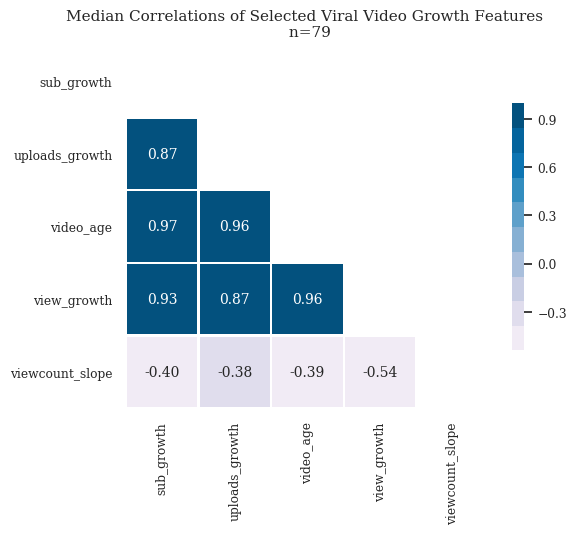

```python
# correlation matrix
median_correlations = url_corr_df.groupby("level_1").median()
median_correlations = median_correlations
median_correlations = median_correlations.loc[
    :, ["sub_growth", "uploads_growth", "video_age", "view_growth", "viewcount_slope"]
]
median_correlations = median_correlations.rename_axis("")


fig, ax = plt.subplots(figsize=(6, 6), dpi=100)
url_count = recent_viral_df["url"].nunique()
ax.set_title(
    f"Median Correlations of Selected Viral Video Growth Features \n n={url_count:,}",
    fontdict={"fontsize": 11},
)
mask = np.triu(median_correlations)
bottom, top = ax.get_ylim()
ax.set_ylim(bottom + 0.5, top - 0.5)
sns.heatmap(
    median_correlations,
    mask=mask,
    cmap=sns.color_palette("PuBu", 10),
    annot=True,
    fmt=".2f",
    square=True,
    linewidths=1,
    cbar_kws={"shrink": 0.5},
    ax=ax,
)
fig.tight_layout();
fig.savefig('viralcorrelation.png', bbox_inches='tight')
```

#### 2.23 Random video sampling for visualisation

```python
random_url = recent_viral_df["url"].sample(1, random_state=77).values[0]
```

```python
# random video correlations
recent_viral_df.loc[
    recent_viral_df["url"] == random_url,
    ["viewcount_slope", "view_growth", "sub_growth", "video_age", "channel_num_uploads_growth"],
].corr()
```

|  | viewcount_slope | view_growth | sub_growth | video_age | channel_num_uploads_growth |
| --- | --- | --- | --- | --- | --- |
| viewcount_slope | 1.000000 | -0.579391 | -0.568359 | -0.486578 | -0.529892 |
| view_growth | -0.579391 | 1.000000 | 0.958733 | 0.840738 | 0.887167 |
| sub_growth | -0.568359 | 0.958733 | 1.000000 | 0.927528 | 0.936461 |
| video_age | -0.486578 | 0.840738 | 0.927528 | 1.000000 | 0.950772 |
| channel_num_uploads_growth | -0.529892 | 0.887167 | 0.936461 | 0.950772 | 1.000000 |

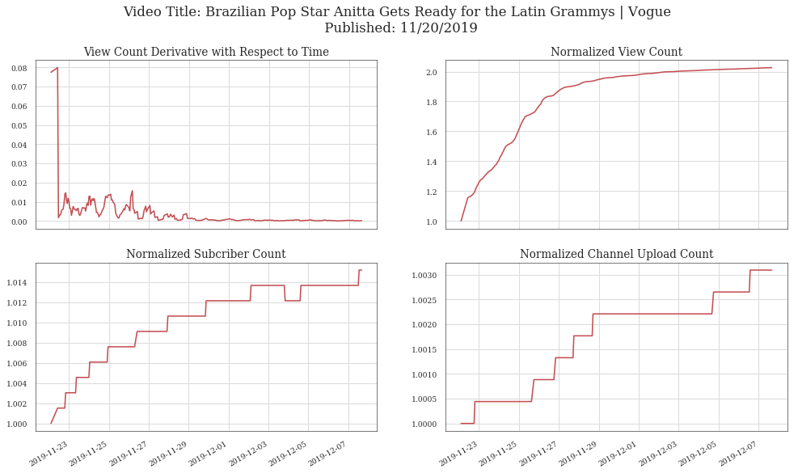

```python
fig, ((ax1, ax2), (ax3, ax4)) = plt.subplots(2, 2, dpi=75, figsize=(16, 9), sharex=False)

url_df = recent_viral_df.loc[recent_viral_df["url"] == random_url, :]
fig.suptitle(
    f'Video Title: {url_df.loc[:, "title"].values[0]} \n Published: {url_df.loc[:, "published"].dt.strftime("%m/%d/%Y").values[0]}',
    fontsize=16,
)
fig.autofmt_xdate()
ax1.plot(url_df.loc[:, "as_of"], url_df.loc[:, "viewcount_slope"], color='r')
ax1.set_title("View Count Derivative with Respect to Time", fontsize=13)
ax2.plot(url_df.loc[:, "as_of"], url_df.loc[:, "view_growth"], color='r')
ax2.set_title("Normalized View Count", fontsize=13)
ax3.plot(url_df.loc[:, "as_of"], url_df.loc[:, "sub_growth"], color='r')
ax3.set_title("Normalized Subcriber Count", fontsize=13)
ax4.plot(url_df.loc[:, "as_of"], url_df.loc[:, "channel_num_uploads_growth"], color='r')
ax4.set_title("Normalized Channel Upload Count", fontsize=13)
fig.savefig("img.png", bbox_inches="tight");
```

#### 2.24 Time series visualisation of all viral videos

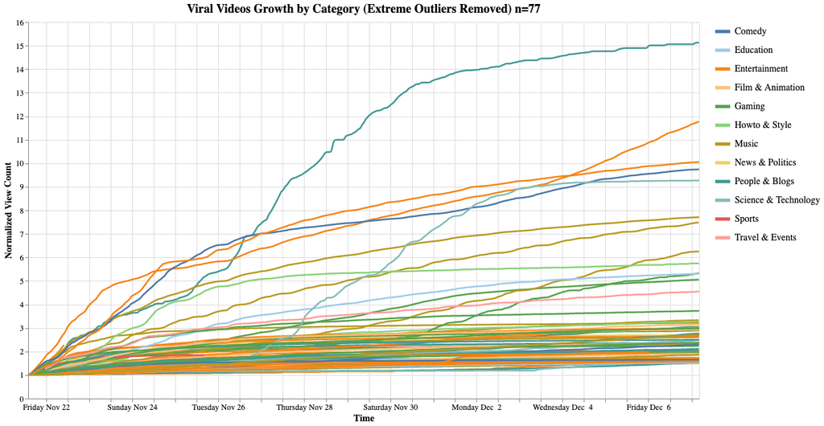

```python
plot_df = recent_viral_df.loc[(recent_viral_df["view_growth_max"] < 25), :]
url_count = plot_df["url"].nunique()
chart = (
    alt.Chart(plot_df)
    .mark_line(interpolate="basis", strokeWidth=2.5)
    .encode(
        x=alt.X("as_of:T", axis=alt.Axis(title="Time", format="%A %b %e")),
        y=alt.Y(
            "view_growth:Q",
            scale=alt.Scale(domain=[1, plot_df["view_growth"].max()]),
            axis=alt.Axis(title="Normalized View Count"),
        ),
        color=alt.Color("category:N", scale=alt.Scale(scheme="tableau20")),
        detail="title",
    )
)
chart = chart.configure(background="white")

chart = chart.configure_legend(
    labelFontSize=14,
    labelFont="Optima Regular",
    strokeWidth=60,
    title=None,
    rowPadding=7,
    symbolSize=500,
    symbolStrokeWidth=5,
)
chart = chart.properties(
    width=1000,
    height=562,
    title=f"Viral Videos Growth by Category (Extreme Outliers Removed) n={url_count}",
)
chart = chart.configure_title(fontSize=18, font="Optima Regular")


chart = chart.configure_axis(
    labelFont="Optima Regular", titleFont="Optima Regular", labelFontSize=12, titleFontSize=14
)

chart
```

### 2.3 Video characteristic analysis including non-viral videos

```python
result = result.sort_values(by="as_of", ascending=False)
df_tots = result.drop_duplicates(subset=["url"], keep="first")
df_tots["likes"] = df_tots["likes"].fillna(0)
df_tots["dislikes"] = df_tots["dislikes"].fillna(0)
```

```python
df_tots["mahala"] = mahalanobis(
    x=df_tots.loc[
        :,
        [
            "likes",
            "dislikes",
            "viewcount",
            "subscriber_count",
            "view_growth",
            "video_age",
            "channel_num_uploads_growth",
        ],
    ],
    data=df_tots.loc[
        :,
        [
            "likes",
            "dislikes",
            "viewcount",
            "subscriber_count",
            "view_growth",
            "video_age",
            "channel_num_uploads_growth",
        ],
    ],
)
```

```python
critical_value = chi2.ppf((1 - 0.01), df=2)
print(
    f"Critical value with two degrees of freedom with 0.01 significance level is {critical_value}"
)
```

```
Critical value with two degrees of freedom with 0.01 significance level is 9.21034037197618
```

```python
# A subselection of videos published in the last 2 years
df_tots = df_tots.loc[df_tots["published"] > (df_tots["as_of"] - timedelta(days=1080))]
```

```python
dummies = pd.get_dummies(df_tots["category"], prefix="category")
```

```python
df_tots = pd.concat([df_tots, dummies], axis=1)
```

```python
# selected columns for correlation plot
corr_cols = [
    "viewcount",
    "likes",
    "dislikes",
    "like/dislike_ratio",
    "length",
    "num_keywords",
    "pct_title_uppercase",
    "view_growth",
    "likes/views",
    "dislikes/views",
    "channel_num_uploads",
    "subscriber_count",
    "category_Autos & Vehicles",
    "category_Comedy",
    "category_Education",
    "category_Entertainment",
    "category_Film & Animation",
    "category_Gaming",
    "category_Howto & Style",
    "category_Music",
    "category_News & Politics",
    "category_People & Blogs",
    "category_Pets & Animals",
    "category_Science & Technology",
    "category_Sports",
    "category_Travel & Events",
]
```

#### 2.33 Plot video characteristics for all videos published in the last 3 years; observations

Now looking at all videos, not just the viral videos, there are more insightful observations. The correlation map includes approximately 1500 videos published in the last 3 years for recency's sake. The amount of `likes` and `dislikes` are very correlated with the `viewcount` of any video. Videos with the category `Music` have the highest positive correlation with viewcount, meaning that music videos get the most views.

With respect to the `like/dislike_ratio` feature, it is not surprising that videos with the `News & Politics` category have a negative correlation.

More formal, academic videos like those with the categories `Science & Technology`, or `News & Politics` have negative correlations with the percentage uppercase in the title, whereas `Gaming` videos have a positive correlation, implying that gaming videos have more clickbait titles. Interestingly enough, `pct_title_uppercase` is also positively correlated with the `likes/views` ratio, meaning that viewers like a video more when the title is all uppercase. This also may be due to the fact that YouTubers that post all uppercase gaming videos also most likely ask their viewers to like their videos explicitly.

Channels that post `News & Politics` videos tend to have the most videos on their channels, with those that upload `Sports` content also showing a positive correlation.

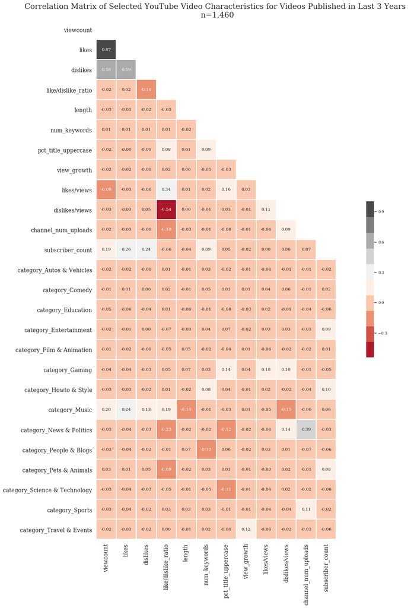

```python
# correlation matrix
df_tots_corr = df_tots[corr_cols].corr()
df_tots_corr = df_tots_corr.loc[:, [x for x in df_tots_corr.columns if 'category_' not in x]]
fig, ax = plt.subplots(figsize=(20, 20), dpi=75)
mask = np.triu(df_tots_corr)
bottom, top = ax.get_ylim()
ax.set_ylim(bottom + 0.5, top - 0.5)
url_count = df_tots['url'].nunique()
ax.set_title(f'Correlation Matrix of Selected YouTube Video Characteristics for Videos Published in Last 3 Years \n n={url_count:,}', fontdict={'size':18})
ax.tick_params(labelsize=13)
sns.heatmap(
    df_tots_corr,
    mask=mask,
    cmap=sns.color_palette("RdGy", 10),
    annot=True,
    fmt=".2f",
    square=True,
    linewidths=1,
    cbar_kws={"shrink": 0.3},
    ax=ax,
)
fig.tight_layout()
fig.savefig('img.png', bbox_inches="tight");
```